# STAT425_CS2_V1

### Fitting a linear model based on the optimal predictors obtained from the **Adjusted $R^2$ Criterion**

We can use the regsubsets function in R to determine the optimal number of predictors using different criteria.

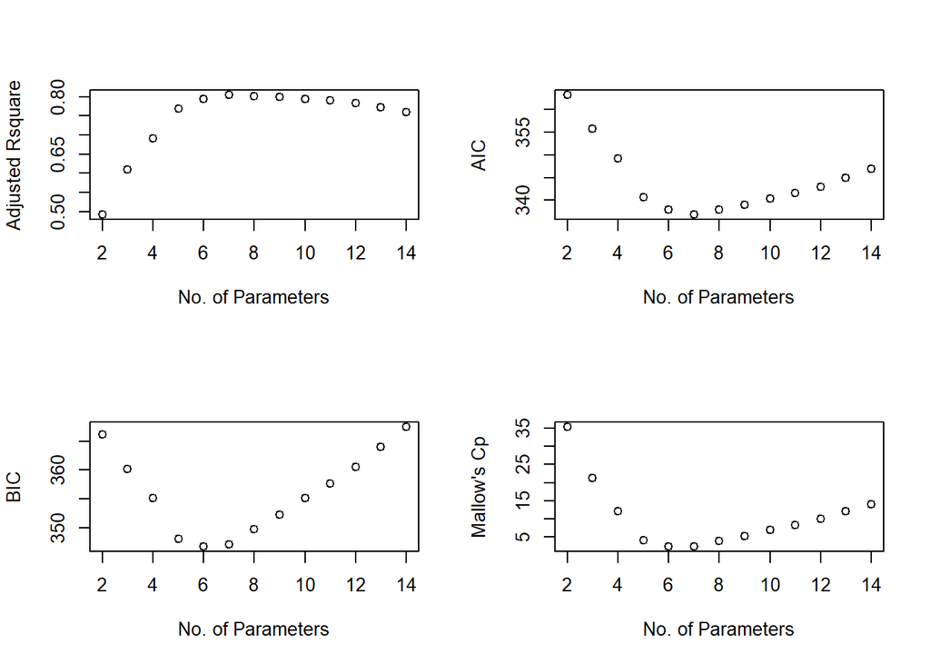

```r
crime.subsets = regsubsets(Crime ~ ., data=train, nvmax = ncol(train)-1)
crime.subsets.summary = summary(crime.subsets)

n = dim(train)[1]
msize = 2:ncol(train)

par(mfrow=c(2,2))
plot(msize, crime.subsets.summary$adjr2, xlab="No. of Parameters", ylab = "Adjusted Rsquare")
Aic = n*log(crime.subsets.summary$rss/n) + 2*msize;
plot(msize, Aic, xlab="No. of Parameters", ylab = "AIC");
Bic = n*log(crime.subsets.summary$rss/n) + msize*log(n);
plot(msize, Bic, xlab="No. of Parameters", ylab = "BIC")
plot(msize, crime.subsets.summary$cp, xlab="No. of Parameters", ylab = "Mallow's Cp")
```

Let’s look at Adj. $R^2$ as our first criterion. The number of columns and the column set which gives the highest adjusted $R^2$ is given below :

```r
which.max(crime.subsets.summary$adjr2)
```

```
## [1] 6
```

```r
#crime.subsets.summary$which[which.max(crime.subsets.summary$adjr2), ]
rs<-crime.subsets.summary
colnames(rs$which)[rs$which[which.max(rs$adjr2),]][-1]
```

```
## [1] "So"   "Ed"   "Po1"  "M.F"  "Ineq" "Time"
```

Let’s fit the model using the suggested columns and get the training and testing RMSE.

```r
col=colnames(rs$which)[rs$which[which.max(rs$adjr2),]][-1]
train.adjR = train[,c('Crime',col)]
test.adjR = test[,c('Crime',col)]

crime.adjR = lm(Crime ~ ., data = train.adjR)
summary(crime.adjR)
```

```
##
## Call:
## lm(formula = Crime ~ ., data = train.adjR)
##
## Residuals:
##     Min      1Q  Median      3Q     Max
## -326.00 -153.14   30.74  108.54  264.02
##
## Coefficients:
##             Estimate Std. Error t value Pr(>|t|)
## (Intercept) -7284.13    1359.38  -5.358 1.48e-05 ***
## So            184.41     116.50   1.583  0.12602
## Ed            180.70      48.73   3.708  0.00105 **
## Po1           125.59      15.37   8.172 1.59e-08 ***
## M.F            33.57      13.38   2.508  0.01901 *
## Ineq           65.39      18.83   3.473  0.00189 **
## Time           22.19       5.22   4.251  0.00026 ***
## ---
## Signif. codes:  0 '***' 0.001 '**' 0.01 '*' 0.05 '.' 0.1 ' ' 1
##
## Residual standard error: 175.6 on 25 degrees of freedom
## Multiple R-squared:  0.8422, Adjusted R-squared:  0.8044
## F-statistic: 22.24 on 6 and 25 DF,  p-value: 6.743e-09
```

```r
ptrain.adjR = predict(crime.adjR, newdata=train.adjR)
ptest.adjR = predict(crime.adjR, newdata=test.adjR)

adjr.lm.train.rmse<-sqrt(mean((train$Crime - ptrain.adjR)^2))
adjr.lm.test.rmse<-sqrt(mean((test$Crime - ptest.adjR)^2))

print(paste("Optimal  Model wrt Adj R2 Train RMSE : ",adjr.lm.train.rmse))
```

```
## [1] "Optimal  Model wrt Adj R2 Train RMSE :  155.194466094224"
```

```r
print(paste("Optimal  Model wrt Adj R2 Test RMSE : ",adjr.lm.test.rmse))
```

```
## [1] "Optimal  Model wrt Adj R2 Test RMSE :  324.000246525426"
```

### Fitting a linear model based on the optimal predictors obtained from the **AIC Criterion**

```r
col = colnames(rs$which)[rs$which[which.min(Aic),]][-1]

col
```

```
## [1] "So"   "Ed"   "Po1"  "M.F"  "Ineq" "Time"
```

```r
train.aic = train[,c('Crime',col)]
test.aic = test[,c('Crime',col)]

crime.aic = lm(Crime ~ ., data = train.aic)
summary(crime.aic)
```

```
##
## Call:
## lm(formula = Crime ~ ., data = train.aic)
##
## Residuals:
##     Min      1Q  Median      3Q     Max
## -326.00 -153.14   30.74  108.54  264.02
##
## Coefficients:
##             Estimate Std. Error t value Pr(>|t|)
## (Intercept) -7284.13    1359.38  -5.358 1.48e-05 ***
## So            184.41     116.50   1.583  0.12602
## Ed            180.70      48.73   3.708  0.00105 **
## Po1           125.59      15.37   8.172 1.59e-08 ***
## M.F            33.57      13.38   2.508  0.01901 *
## Ineq           65.39      18.83   3.473  0.00189 **
## Time           22.19       5.22   4.251  0.00026 ***
## ---
## Signif. codes:  0 '***' 0.001 '**' 0.01 '*' 0.05 '.' 0.1 ' ' 1
##
## Residual standard error: 175.6 on 25 degrees of freedom
## Multiple R-squared:  0.8422, Adjusted R-squared:  0.8044
## F-statistic: 22.24 on 6 and 25 DF,  p-value: 6.743e-09
```

```r
ptrain.aic = predict(crime.aic, newdata=train.aic)
ptest.aic = predict(crime.aic, newdata=test.aic)

aic.lm.train.rmse<-sqrt(mean((train$Crime - ptrain.aic)^2))
aic.lm.test.rmse<-sqrt(mean((test$Crime - ptest.aic)^2))

print(paste("Optimal  Model wrt AIC Train RMSE : ",aic.lm.train.rmse))
```

```
## [1] "Optimal  Model wrt AIC Train RMSE :  155.194466094224"
```

```r
print(paste("Optimal  Model wrt AIC Test RMSE : ",aic.lm.test.rmse))
```

```
## [1] "Optimal  Model wrt AIC Test RMSE :  324.000246525426"
```

AIC yields the same set of optimal predictors as Adjusted $R^2$ and therefore has the same train and test RMSE.

### Fitting a linear model based on the optimal predictors obtained from the **BIC Criterion**

```r
col = colnames(rs$which)[rs$which[which.min(Bic),]][-1]

col
```

```
## [1] "Ed"   "Po1"  "M.F"  "Ineq" "Time"
```

```r
train.bic = train[,c('Crime',col)]
test.bic = test[,c('Crime',col)]

crime.bic = lm(Crime ~ ., data = train.bic)

summary(crime.bic)
```

```
##
## Call:
## lm(formula = Crime ~ ., data = train.bic)
##
## Residuals:
##     Min      1Q  Median      3Q     Max
## -306.26  -86.64    7.13  121.55  319.99
##
## Coefficients:
##              Estimate Std. Error t value Pr(>|t|)
## (Intercept) -6805.341   1363.137  -4.992 3.43e-05 ***
## Ed            172.222     49.823   3.457 0.001893 **
## Po1           133.688     14.904   8.970 1.94e-09 ***
## M.F            26.639     13.010   2.048 0.050822 .
## Ineq           84.515     14.850   5.691 5.48e-06 ***
## Time           19.546      5.087   3.842 0.000704 ***
## ---
## Signif. codes:  0 '***' 0.001 '**' 0.01 '*' 0.05 '.' 0.1 ' ' 1
##
## Residual standard error: 180.6 on 26 degrees of freedom
## Multiple R-squared:  0.8264, Adjusted R-squared:  0.793
## F-statistic: 24.76 on 5 and 26 DF,  p-value: 4.036e-09
```

```r
ptrain.bic = predict(crime.bic, newdata=train.bic)
ptest.bic = predict(crime.bic, newdata=test.bic)

bic.lm.train.rmse<-sqrt(mean((train$Crime - ptrain.bic)^2))
bic.lm.test.rmse<-sqrt(mean((test$Crime - ptest.bic)^2))

print(paste("Optimal  Model wrt BIC Train RMSE : ",bic.lm.train.rmse))
```

```
## [1] "Optimal  Model wrt BIC Train RMSE :  162.785704117715"
```

```r
print(paste("Optimal  Model wrt BIC Test RMSE : ",bic.lm.test.rmse))
```

```
## [1] "Optimal  Model wrt BIC Test RMSE :  320.938721946138"
```

We can observe for BIC that due to a smaller number of predictors the Train RMSE has increased but the Test RMSE has reduced slightly as compared to AIC and Adjusted $R^2$.

### Fitting a linear model based on the optimal predictors obtained from the **Mallow’s $C_p$ Criterion**

```r
col=colnames(rs$which)[rs$which[which.min(rs$cp),]][-1]
train.cp = train[,c('Crime',col)]
test.cp = test[,c('Crime',col)]

crime.cp = lm(Crime ~ ., data = train.cp)
summary(crime.cp)
```

```
##
## Call:
## lm(formula = Crime ~ ., data = train.cp)
##
## Residuals:
##     Min      1Q  Median      3Q     Max
## -326.00 -153.14   30.74  108.54  264.02
##
## Coefficients:
##             Estimate Std. Error t value Pr(>|t|)
## (Intercept) -7284.13    1359.38  -5.358 1.48e-05 ***
## So            184.41     116.50   1.583  0.12602
## Ed            180.70      48.73   3.708  0.00105 **
## Po1           125.59      15.37   8.172 1.59e-08 ***
## M.F            33.57      13.38   2.508  0.01901 *
## Ineq           65.39      18.83   3.473  0.00189 **
## Time           22.19       5.22   4.251  0.00026 ***
## ---
## Signif. codes:  0 '***' 0.001 '**' 0.01 '*' 0.05 '.' 0.1 ' ' 1
##
## Residual standard error: 175.6 on 25 degrees of freedom
## Multiple R-squared:  0.8422, Adjusted R-squared:  0.8044
## F-statistic: 22.24 on 6 and 25 DF,  p-value: 6.743e-09
```

```r
ptrain.cp = predict(crime.cp, newdata=train.cp)
ptest.cp = predict(crime.cp, newdata=test.cp)

cp.lm.train.rmse<-sqrt(mean((train$Crime - ptrain.cp)^2))
cp.lm.test.rmse<-sqrt(mean((test$Crime - ptest.cp)^2))

print(paste("Optimal  Model wrt Mallow's Cp Train RMSE : ",cp.lm.train.rmse))
```

```
## [1] "Optimal  Model wrt Mallow's Cp Train RMSE :  155.194466094224"
```

```r
print(paste("Optimal  Model wrt Mallow's Cp Test RMSE : ",cp.lm.test.rmse))
```

```
## [1] "Optimal  Model wrt Mallow's Cp Test RMSE :  324.000246525426"
```

We obtain the same set of predictors as the one we obtain from AIC and Adjusted $R^2$.

### Fitting a **Ridge regression model** and reporting the training and testing errors

Now we will use 10 fold cross validation to find the optimal parameter $\lambda$ to fit the ridge regression model.

```r
library(glmnet)
set.seed(425)
xtrain = model.matrix(Crime ~ ., data = train)[,-1]
#head(xtrain)
ytrain = train$Crime
xtest = model.matrix(Crime ~ ., data = test)[,-1]
ytest = test$Crime

grid =  10^seq(1,2, length = 10000)
mod.ridge = cv.glmnet(xtrain, ytrain, alpha=0, lambda=grid,nfold=10)
lambda.best = mod.ridge$lambda.min
mod.ridge
```

```
##
## Call:  cv.glmnet(x = xtrain, y = ytrain, lambda = grid, nfolds = 10,      alpha = 0)
##
## Measure: Mean-Squared Error
##
##     Lambda Index Measure    SE Nonzero
## min  25.69  5902   64588 10809      13
## 1se 100.00     1   70652 11090      13
```

```r
model_ridge_best <- glmnet(y = ytrain,
                           x = xtrain,
                           alpha = 0,
                           lambda =  lambda.best,nfold=10)
```

The optimal value of $\lambda$ is 25.69.

Let’s check the Minimum cross validation error from the different iterations.

```r
sqrt(min(mod.ridge$cvm))
```

```
## [1] 254.1416
```

Finally, let’s report the train and test RMSE from the ridge regression

```r
ridge_train_pred <- predict(model_ridge_best, s =  lambda.best, newx = xtrain)
ridge_test_pred <- predict(model_ridge_best, s =  lambda.best, newx = xtest)

ridge_train_mse <- sqrt(mean((ridge_train_pred - train$Crime)^2))
ridge_test_mse <- sqrt(mean((ridge_test_pred - test$Crime)^2))

print(paste("Ridge Regression Train RMSE ",ridge_train_mse))
```

```
## [1] "Ridge Regression Train RMSE  154.148585751419"
```

```r
print(paste("Ridge Regression Test RMSE ",ridge_test_mse))
```

```
## [1] "Ridge Regression Test RMSE  290.627542197664"
```

### Fitting a **Lasso regression model** and reporting the training and testing errors

Similar to ridge regression let’s predict the crime rate using Lasso and check the training and testing RMSE.

```r
set.seed(425)
grid =  10^seq(-2,1, length = 100000)
mod.lasso = cv.glmnet(xtrain, ytrain, alpha=1, lambda=grid,nfold=10)
lambda.best = mod.lasso$lambda.min
mod.lasso
```

```
##
## Call:  cv.glmnet(x = xtrain, y = ytrain, lambda = grid, nfolds = 10,      alpha = 1)
##
## Measure: Mean-Squared Error
##
##     Lambda Index Measure    SE Nonzero
## min  4.072 13006   66409 10790      12
## 1se 10.000     1   69832 14402      11
```

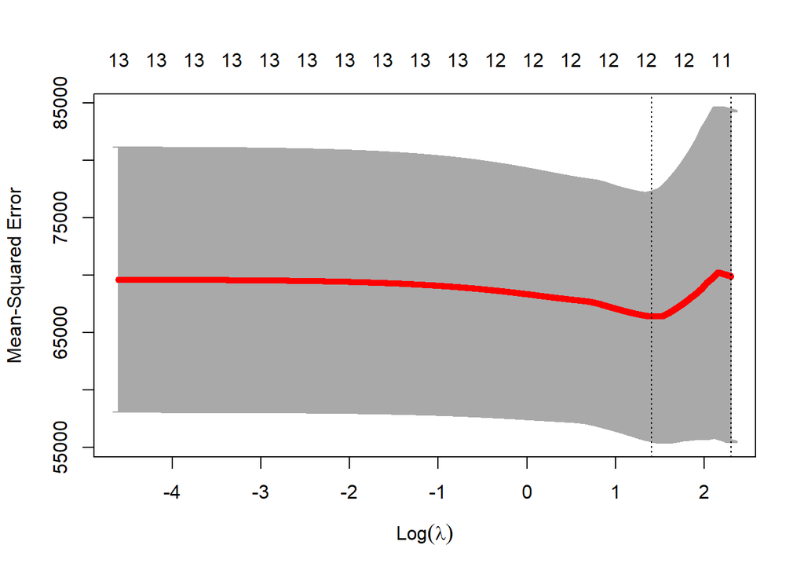

```r
model_lasso_best <- glmnet(y = ytrain,
                           x = xtrain,
                           alpha = 1,
                           lambda =  lambda.best,nfold=10)


plot(mod.lasso)
```

The optimal value of lambda is 4.072. Let’s check the minimu Cross validation error for the Lasso Regression model.

```r
sqrt(min(mod.lasso$cvm))
```

```
## [1] 257.6999
```

Finally, let’s find out the Training and Test RMSE for Lasso Regression

```r
lasso_train_pred <- predict(model_lasso_best, s =  lambda.best, newx = xtrain)
lasso_test_pred <- predict(model_lasso_best, s =  lambda.best, newx = xtest)

lasso_train_rmse <- sqrt(mean((lasso_train_pred - train$Crime)^2))
lasso_test_rmse <- sqrt(mean((lasso_test_pred - test$Crime)^2))

print(paste("Lasso Regression Train RMSE ",lasso_train_rmse))
```

```
## [1] "Lasso Regression Train RMSE  148.03560281783"
```

```r
print(paste("Lasso Regression Test RMSE ",lasso_test_rmse))
```

```
## [1] "Lasso Regression Test RMSE  291.879948754964"
```

### Fitting a **Principal Components Regression (PCR) model** and reporting the training and testing errors

```r
library(pls)
```

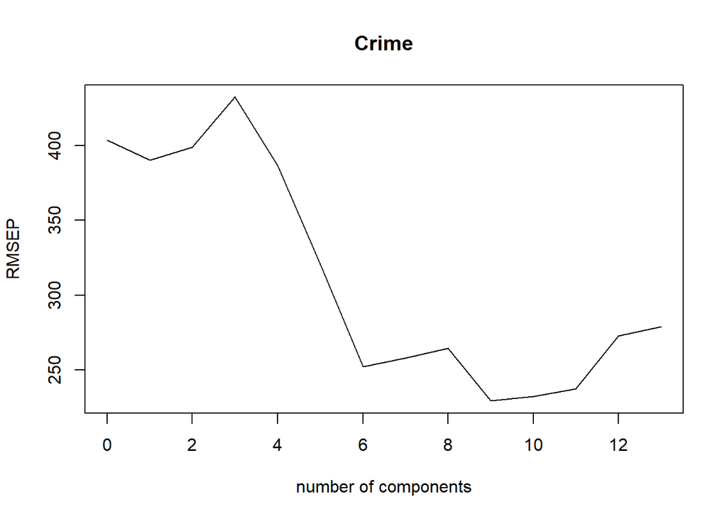

```r
set.seed(425)

model.pcr = pcr(Crime ~., data=train, validation="CV")
plot(RMSEP(model.pcr, estimate="CV"))
```

Let’s find the number of components which results in the min RMSE

```r
M = which.min(RMSEP(model.pcr, estimate="CV")$val)
M
```

```
## [1] 10
```

So there are 9 principal components (10 including intercept ) in the model which gives the least cross validation RMSE. Let’s find out that minimum CV.

```r
min(RMSEP(model.pcr, estimate="CV")$val)
```

```
## [1] 229.5424
```

Finally, let’s find out the training and testing RMSE for the PCR Model

```r
ptrain.pcr = predict(model.pcr, train, ncomp=9)
ptest.pcr = predict(model.pcr, test, ncomp=9)



pcr_train_rmse <- sqrt(mean((ptrain.pcr - train$Crime)^2))
pcr_test_rmse <- sqrt(mean((ptest.pcr - test$Crime)^2))

print(paste("PCR Train RMSE ",pcr_train_rmse))
```

```
## [1] "PCR Train RMSE  152.647206213103"
```

```r
print(paste("PCR Test RMSE ",pcr_test_rmse))
```

```
## [1] "PCR Test RMSE  309.883430264062"
```

## Final Summary of all models

Let us summarise the prediction RMSE from all the models considered in the form of a visualisation

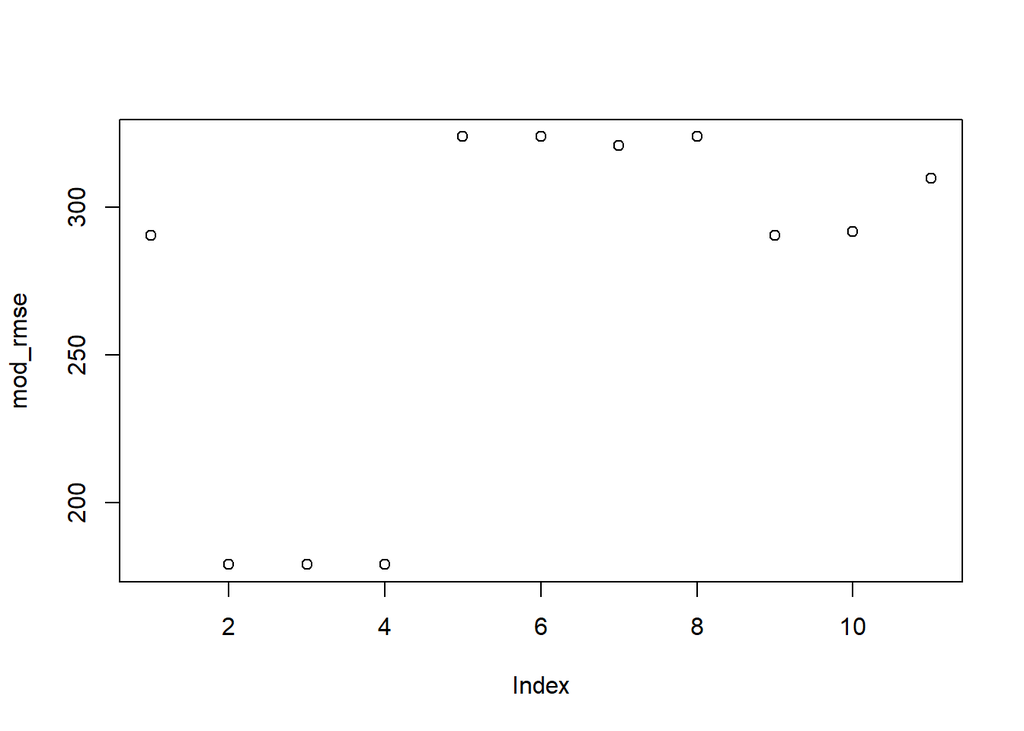

```r
mod_names<-c('Linear Regression','Forward Selection','Backward Selection','Both Ways Selection','Adjuster R2','AIC','BIC',"Mallow's Cp",'Ridge Regression','Lasso Regression','PCR')

mod_rmse<-c(lm.test.rmse,forward.test.rmse,back.lm.crime.test.rmse,back.lm.crime.test.rmse,adjr.lm.test.rmse,aic.lm.test.rmse,bic.lm.test.rmse,cp.lm.test.rmse,ridge_test_mse,lasso_test_rmse,pcr_test_rmse)

plot(mod_rmse)
```